# ROC Curves

Rachel Wood

2023-07-17

Since we are proposing the distance moved reflects the amount a node has moved, it makes sense to simply normalise the average distance moved for groups to sum to 1. We can then plot an ROC curve for each number of components to decide how many components to consider.

# Simulations

We use the `ClaritySim` package to generate our data sets of data. We will start with a tree and a fixed mixture. We start by using a mixture of the nodes furthest away from each other to test our methods:

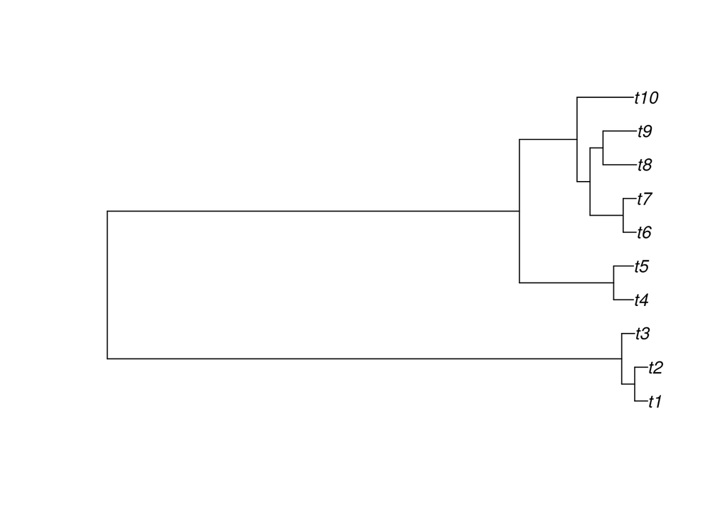

```r
library(ClaritySim)
set.seed(124)
n <- 100
k <- 10
l <- 100
original <- simulateCoalescent(n, k, l,
                         sigma0 = 0.2,
                         sigma = 0.5,
                         Amodel = "uniform",
                         alpha = 0,
                         minedge = 0.1)
 # Simlulate 100 objects in a 10 dimensional latent space
plot(original$tree)
```

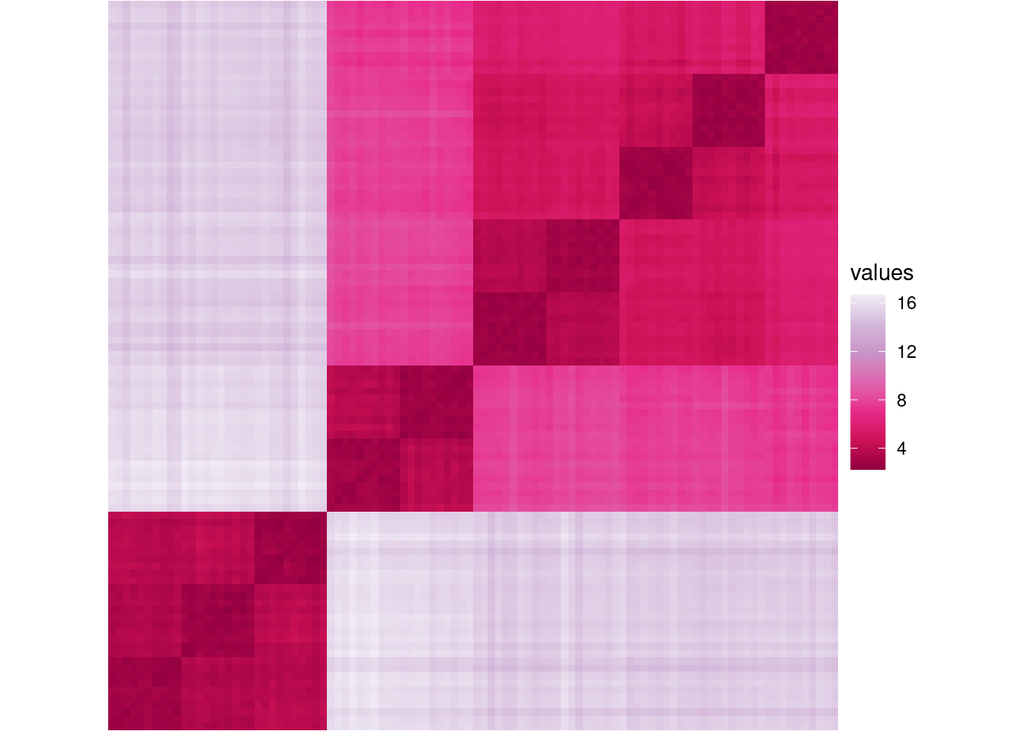

```r
original_similar <- expand.grid(
    Subjects = as.factor(1:100),
    Subject = as.factor(1:100))
original_similar$values <- c(original$Y)

ggplot(data = original_similar, aes(x = Subjects, y = Subject)) +
  geom_tile(aes(fill = values)) +
  theme(legend.position = "none", panel.border = element_rect(linewidth = 10)) +
   theme_void() + coord_fixed()
```

We then alter the scaling of the branch lengths to affect the noisy-ness of the data. For any $r$, we can set the min branch length to be $r$ and the maximum branch length to be $r$.

```r
set.seed(123456)
mix <- original
mix$edges <- c()
library(ape)
mixed_fixed <- mixCoalescent(
    original,
    fraction = 1,
    transform = FALSE)
mixture <- mixed_fixed$edges
```

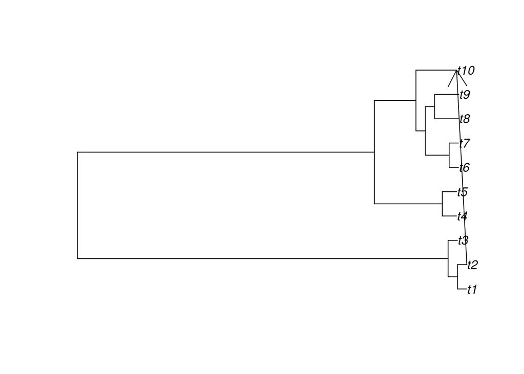

```r
plot(mixed_fixed$tree)
edges(mixture[1], mixture[2], arrows = 1)
```

```r
library(dplyr)
library(tidyverse)
source("UASE.R")
source("distances.R")
similarity <- cbind(original$Y, mixed_fixed$Y)
uase <- UASE(similarity, d = 12, groups)
```

```r
distances <- apply(
    as.matrix(1:12, nrow = 1),
    MARGIN = 1,
    FUN = function(ii) {
        distance_moved(uase$right, d = ii, scale = FALSE)
    })

groups <- rep(1:10, each = 10)
uase_distance_groups <- group_distances(
    distances = distances,
    d = 12,
    groups = groups)
uase_distance_groups <- uase_distance_groups %>% # nolint
    group_by(Group) %>%
    mutate(Probability = Distances / sum(Distances),
    True_Anomaly = as.numeric(Group == 10))
```

```r
max_thresh <- max(uase_distance_groups$Probability)
thresholds <- seq(0, max_thresh + 0.05, length.out = 100)

roc_data <- tibble(
    Threshold = NA,
    Components = NA,
    True_Positive_Rate = NA,
    False_Positive_Rate = NA
)
pos <- uase_distance_groups %>%
    filter(True_Anomaly == 1) %>%
    nrow() / 12
neg <- uase_distance_groups %>%
    filter(True_Anomaly == 0) %>%
    nrow() / 12

roc_data <- roc_data[-1, ]

for (i in 1:length(thresholds)) {
    current_threshold <- thresholds[i]
    current_class <- uase_distance_groups %>%
        mutate(Anomaly = as.numeric(Probability >= current_threshold),
               True_Positive = as.numeric(Anomaly == 1 & True_Anomaly == 1),
               False_Positive = as.numeric(Anomaly == 1 & True_Anomaly == 0)) %>%
        group_by(Components) %>%
        summarise(Threshold = current_threshold,
                  True_Positive_Rate = sum(True_Positive) / pos,
                   False_Positive_Rate = sum(False_Positive) / neg)
    roc_data <- rbind(roc_data, current_class)
}
```

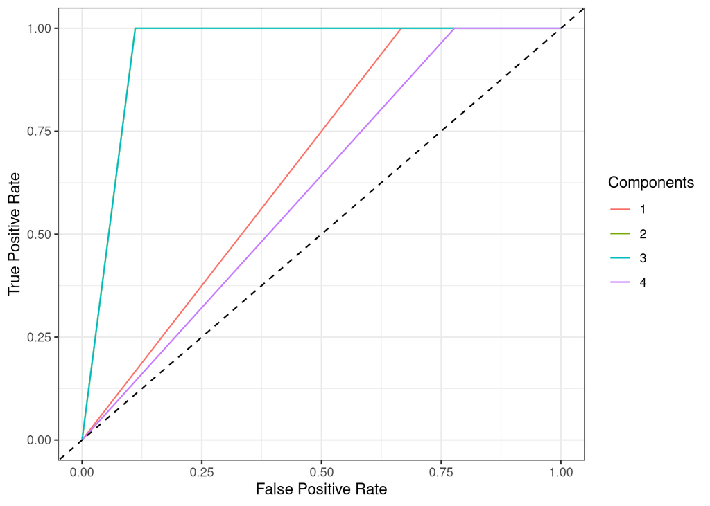

```r
plot <- roc_data %>%
    filter(!((False_Positive_Rate == 0 & True_Positive_Rate > 0.1) |
    (True_Positive_Rate == 0 & False_Positive_Rate > 0.1))) %>%
    filter(Components %in% c(1, 2, 3, 4))

ggplot(data = plot, aes(x = False_Positive_Rate, y = True_Positive_Rate)) +
    geom_line(aes(colour = Components)) +
    geom_abline(slope = 1, intercept = 0, linetype = "dashed") +
    theme_bw() +
    labs(x = "False Positive Rate", y = "True Positive Rate")
```